# Data Center Opposition Movement Profile in the United States

Time trend, geography, partisanship, and socio-economic contexts

Author

Jaewook Lee

Published

October 31, 2026

# Summary

These descriptive figures suggest three early patterns in the tracker, focusing on the United States. First, documented opposition to data center development took off in 2024 and has grown rapidly since then. The 2026 count should be read as partial because the tracker is current through 2026-09-30.

Second, documented local movements appear across 195 counties in 48 states. Wisconsin has the most counties (12), followed by Georgia (11), then Indiana, Kentucky, Michigan, North Carolina, and Virginia (10 each). Forty percent of opposition counties are in the South and 34 percent are in the Midwest. Counting statewide efforts as well, the tracker spans 49 states; Vermont is the only one with no local case, represented solely by a statewide bill to pause AI data centers, while Hawaii has no documented movement at either level. About 76 percent of opposition counties are classified as large-city or suburban, compared with 38 percent of all US counties in the comparison data.

Third, the mapped opposition is not confined to one partisan or socio-economic profile. Of the 194 opposition counties with complete election data, 115 voted Republican and 79 voted Democratic in 2024. Their median household income is about $77,244, compared with $65,346 across all counties in the comparison data; five-year income growth is similar (26.2 versus 26.9 percent). Opposition counties also have a lower median white non-Hispanic share (71 versus 80 percent) and a higher median college-attainment share (32 versus 22 percent). These county-level descriptions do not establish why opposition arises, but they show that documented movements span varied political, economic, and demographic contexts.

# Annual Trend

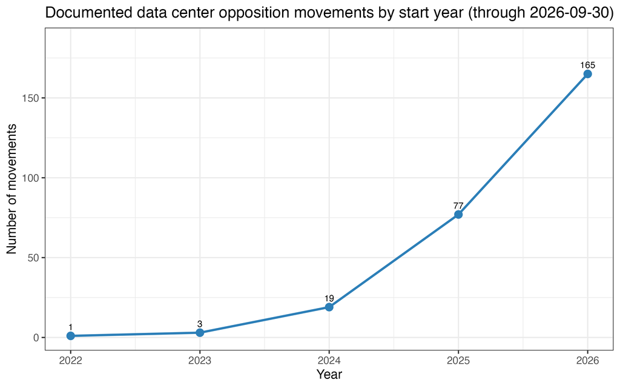

Documented data center opposition movements by start year.

# Where Opposition Happens

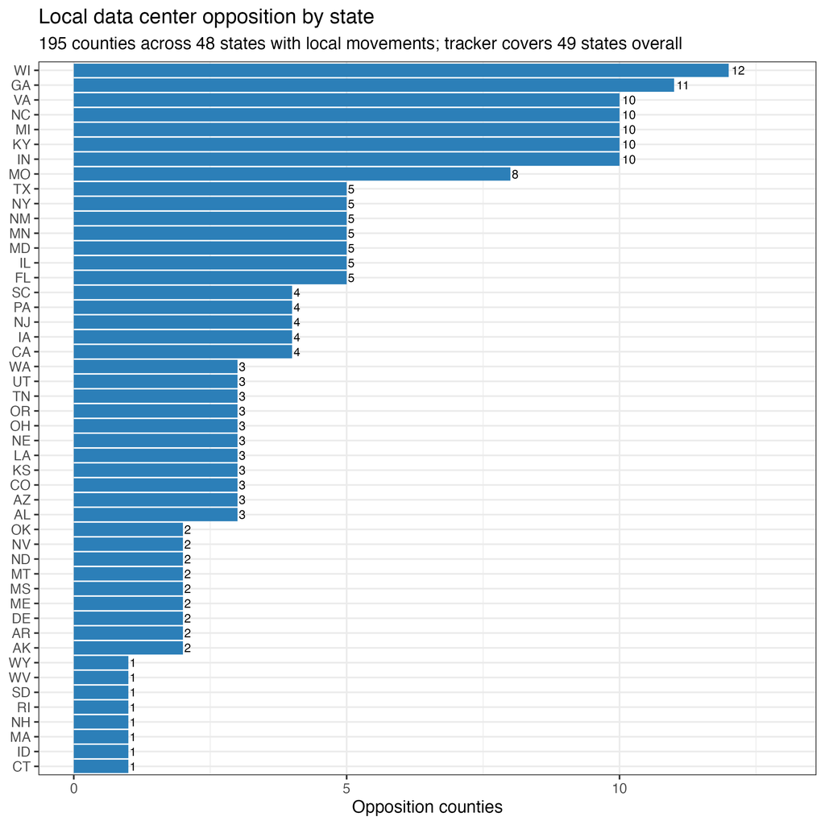

Number of movement counties by state.

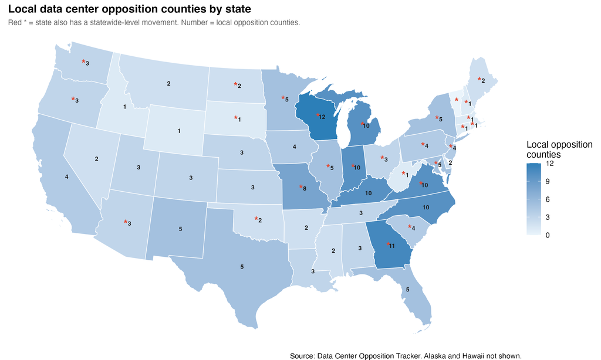

State choropleth map of local opposition counties. Numbers show the count per state; asterisks mark states with at least one statewide-level movement.

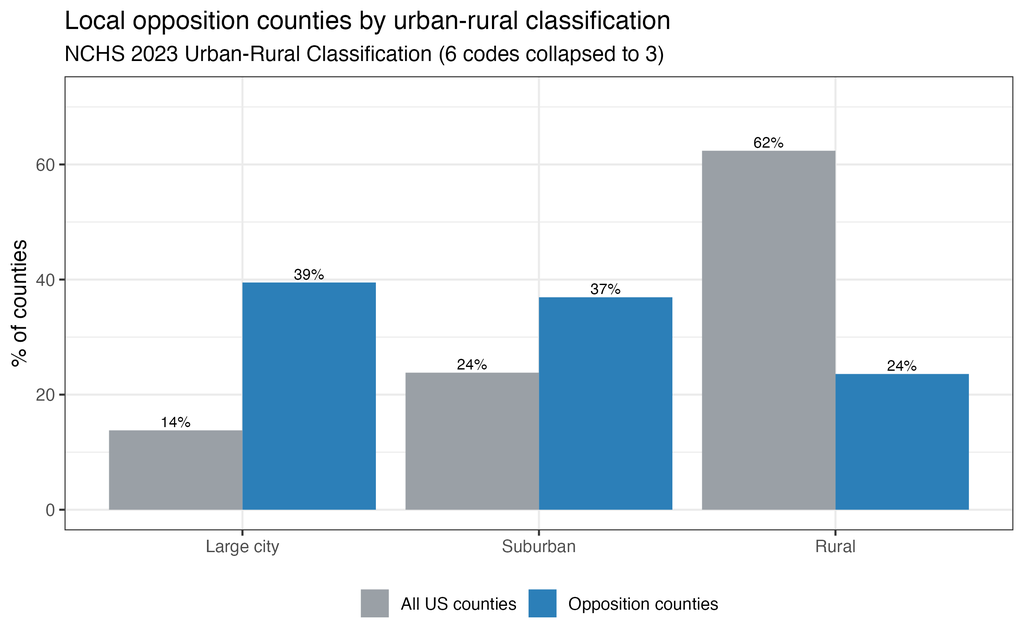

Urban-rural breakdown of opposition counties versus all US counties.

# Income Level and Partisanship

Each chart marks both the national median and the opposition-county median for reference. Opposition counties cluster to the right of the national median, consistent with their higher-income, more urban and suburban profile.

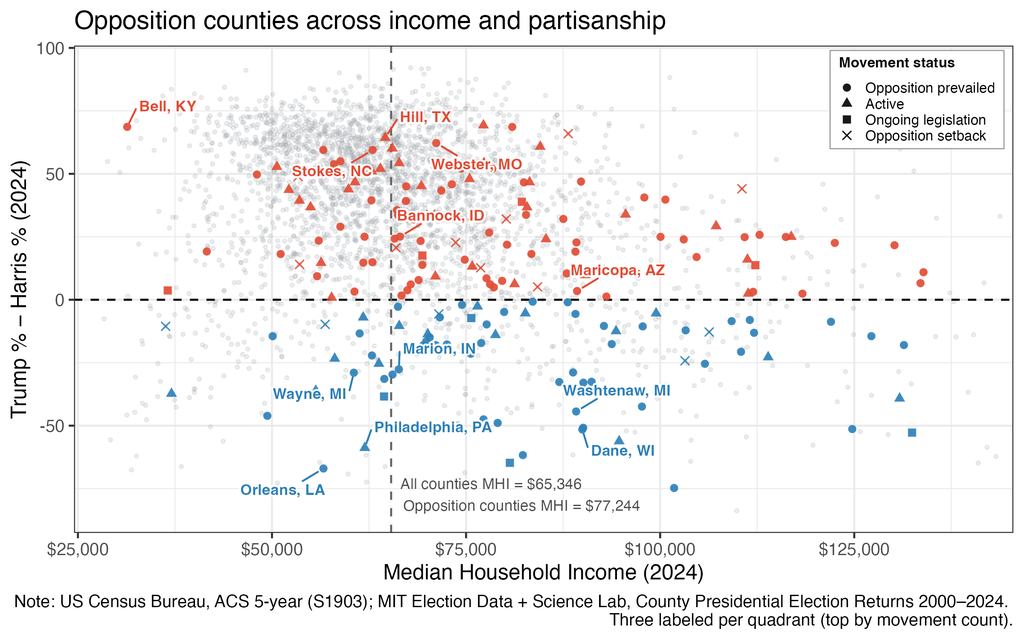

Median household income and 2024 presidential margin.

# Income Growth and Partisanship

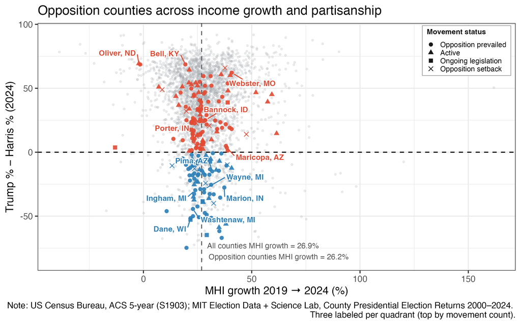

Five-year median household income growth and 2024 presidential margin.

# Race and Educational Attainment

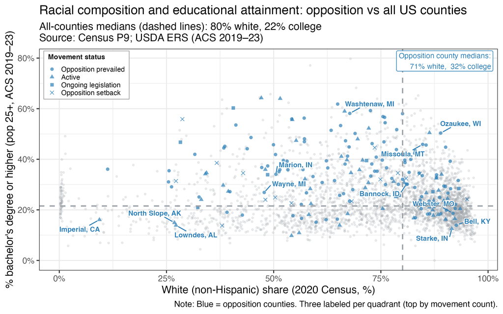

White non-Hispanic share and college attainment: opposition counties versus all US counties.